# Лабораторная работа №8

Модель конкуренции двух фирм

Майсаров А. М.

Российский университет дружбы народов, Москва, Россия

15 апреля 2023

# Информация

## Докладчик

- Майсаров Аббас Мурадович
- студент уч. группы НФИбд-01-20
- Российский университет дружбы народов
- 1032200530@pfur.ru

# Вводная часть

## Актуальность

- Необходимость навыков моделирования реальных математических задач, построение графиков.

## Объект и предмет исследования

- Язык программирования Julia
- Язык моделирования Modelica
- Модель конкуренции двух фирм

## Цели и задачи

- Продолжить знакомство с функционалом языков Julia и Modelica.
- Описать модель конкуренции двух фирм с помощью данных языков.
- Построить графики состояния систем в соответствии с поставленными задачами.

## Материалы и методы

- Языки:
  - язык программирования Julia
  - язык моделирования Modelica
- Дополнительный комплекс программ:
  - Программное обеспечение OpenModelica

# Процесс выполнения работы

# Формулировка задания

Рассмотреть два случая конкуренции двух фирм: в первом случае борьба между фирмами ведется только рыночными методами. Во втором случае, помимо экономических факторов, борьба ведется при помощи социально-психологических факторов.

1. Построить графики изменения оборотных средств фирмы 1 и фирмы 2 без учета постоянных издержек и с веденной нормировкой для случая 1.
2. Постройте графики изменения оборотных средств фирмы 1 и фирмы 2 без учета постоянных издержек и с веденной нормировкой для случая 2.

# Теоретическое введение

## Теоретическое введение 1

Рассмотрим случай конкуренции между двумя фирмами, которые ведут борьбу только рыночными методами.

Система уравнений для первого случая принимает вид:

$$\frac{dM_1}{d\theta} = M_1 -
\frac{b}{c_1} M_1 M_2 - \frac{a_1}{c_1} M_1^2$$

$$\frac{dM_2}{d\theta} =
\frac{c_2}{c_1}M_2 - \frac{b}{c_1} M_1 M_2 - \frac{a_2}{c_1} M_2^2,$$

где $\delta = \frac{t}{c_1}$ — нормировка времени (безразмерное время), $a_1 = \frac{p_{cr}}{\tau_1^2 \tilde p_1^2 Nq}$, $a_2 = \frac{p_{cr}}{\tau_2^2 \tilde p_2^2 Nq}$, $b = \frac{p_{cr}}{\tau_1^2 \tilde p_1^2 \tau_2^2 \tilde p_2^2 Nq}$, $c_1=\frac{p_{cr} - \tilde p_1}{\tau_1 \tilde p_1}$, $c_2=\frac{p_{cr} - \tilde p_2}{\tau_2 \tilde p_2}$.

## Теоретическое введение 2

Рассмотрим случай конкуренции между двумя фирмами, при котором используются также и социально-психологические факторы.

В данном случае система уравнений принимает вид:

$$\frac{dM_1}{d\theta} = M_1 -
\frac{b}{c_1} M_1 M_2 - \frac{a_1}{c_1} M_1^2$$

$$\frac{dM_2}{d\theta} =
\frac{c_2}{c_1}M_2 - (\frac{b}{c_1} + 0.00031) M_1 M_2 - \frac{a_2}{c_1}
M_2^2,$$

## Теоретическое введение 3

Также заметим, что *p*<sub>*c**r*</sub>, *p̃*<sub>1, 2</sub>, *N* указаны в тысячах единиц, а значения *M*<sub>1, 2</sub> — в миллионах единиц.

# Julia

## График для случая 1

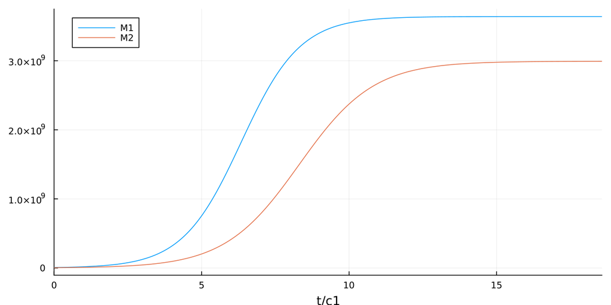

## График для в случая 2

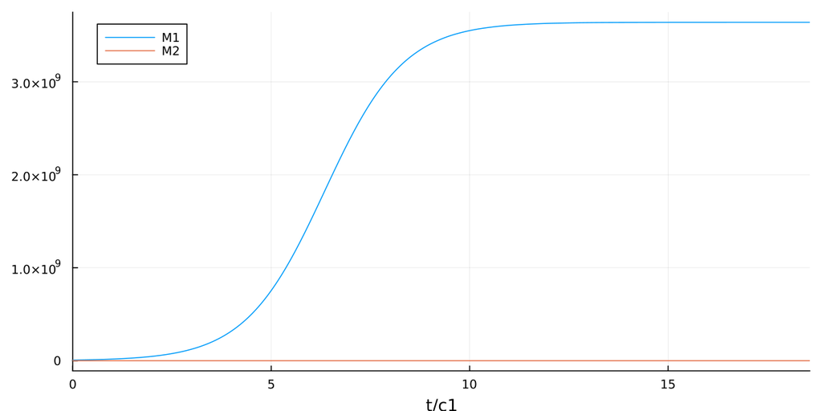

# OpenModelica

## График для случая 1

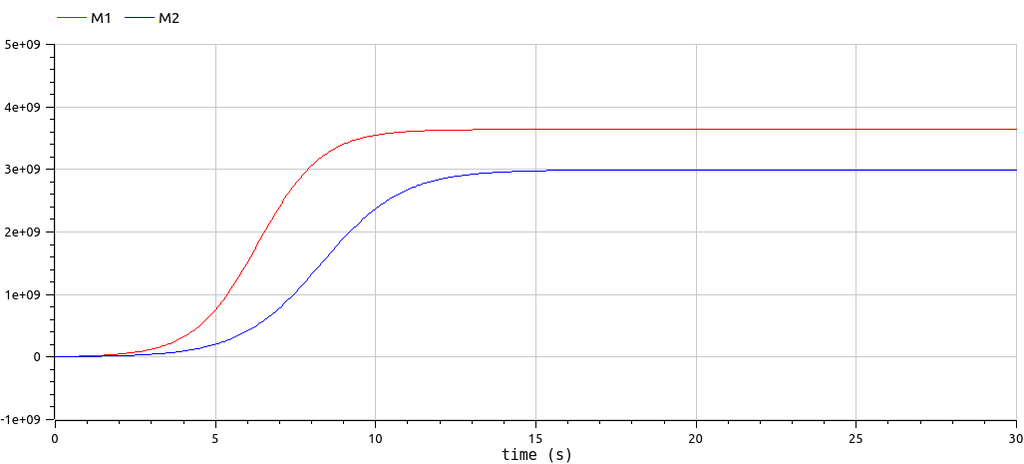

## График для в случая 2

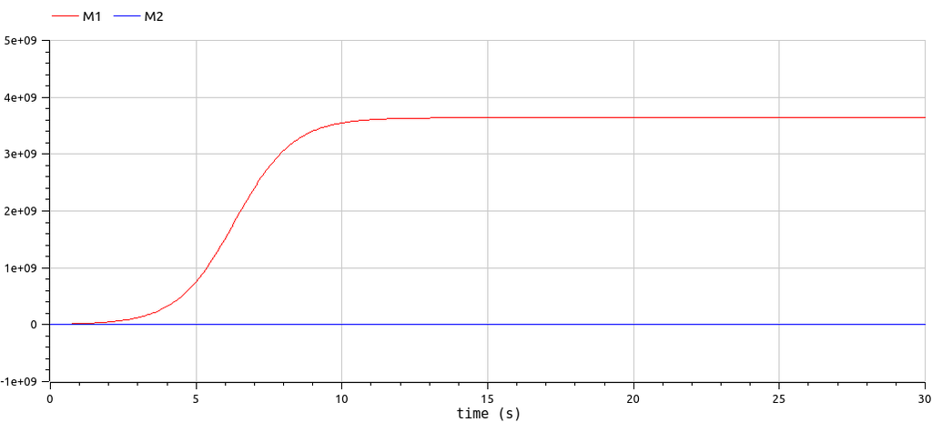

# Результаты

- Описана математическая модель конкуренции двух фирм с помощью языков Julia и Modelica.
- Построены графики состояния систем в соответствии с поставленными задачами.

## Вывод

Продолжил знакомство с функционалом языка программирования Julia и языка моделирования Modelica, а также с функционалом программного обеспечения OpenModelica. Используя эти средства, построил математическую модель конкуренции двух фирм.